# Stock Report in Relation to Political Factors

David Osuch, Xue(Tracy) Feng, Amber Fording

2021-10-13

## Stock Buying Recommendation: *Walmart, Tesla, & Netflix*

Our team studied the effects political factors from two Presidential candidates in 2020 being Donald Trump and Joe Biden relate to thirty-two popular stocks. We utilized the Dow Jones as a benchmark, while considering Industrial outputs for each of the two Candidates. Our analysis proves that Walmart, Tesla, and Netflix would be most *positively* exposed to political factors.

## Data Processing

**Data Normalization** - In order to consider each of the thirty stocks on a level playing field, we normalized the stock price data from *stocks2020.csv* to a scale ranging from 0 to 1. The closer to 1 illustrates a higher stock price within that specific stock. Our Output of the normalized data is shown below:

|  | date | norm_DJI | norm_AAPL | norm_NFLX | norm_AMZN | norm_K | norm_TSLA | norm_LMT | norm_MCD | norm_BAC | norm_NYT | norm_XOM | norm_TWTR | norm_FB | norm_GOOGL | norm_GEO | norm_WMT | norm_ARCH | norm_RSX | norm_MLM | norm_CAT | norm_BDX | norm_BEP | norm_NEE | norm_AY | norm_FSLR | norm_CGC | norm_WKHS | norm_UNH | … |
| --- | --- | --- | --- | --- | --- | --- | --- | --- | --- | --- | --- | --- | --- | --- | --- | --- | --- | --- | --- | --- | --- | --- | --- | --- | --- | --- | --- | --- | --- | --- |
| 1 | 2020-01-02 |  | 0.235677313725216 | 0.120173850302242 | 0.119363410891697 | 0.810126420591115 | 0.0221724063140575 | 0.751732557306434 | 0.688242833560621 | 1 | 0.179033622004627 | 1 | 0.30410390623277 | 0.403863206872901 | 0.408061417251425 | 0.877720207253886 | 0.305498605970169 | 0.998619873844245 | 0.927975815011372 | 0.940846352890751 | 0.649402336823583 | 0.842524494910361 | 0.305704199001489 | 0.440389622402648 | 0.336520977389755 | 0.360725719287925 | 0.539698962117281 | 0.0549261929282527 | 0.602864876406586 | … |
| 2 | 2020-01-03 | 0.849827010718221 | 0.226619911537458 | 0.105001741647642 | 0.106941833061624 | 0.83083994068815 | 0.0262670999216407 | 0.839864991612574 | 0.680570572336222 | 0.957858938374655 | 0.186798937601289 | 0.985551331164732 | 0.281074705670939 | 0.396833435265985 | 0.398772804418913 | 0.819689119170984 | 0.283955659408219 | 1 | 0.88855193328279 | 0.935023487110038 | 0.626272668919278 | 0.807985056735987 | 0.317352097545106 | 0.45353336797691 | 0.346994519717918 | 0.357790794111895 | 0.52776336274001 | 0.0549261929282527 | 0.58458881509303 | … |
| 3 | 2020-01-06 | 0.855623401262301 | 0.233971243501179 | 0.143533398580836 | 0.121988971635087 | 0.827387812003003 | 0.029006538816197 | 0.836001115927506 | 0.70488438441961 | 0.955011330012035 | 0.188955969711473 | 0.999239569094054 | 0.284617634621129 | 0.421722654873313 | 0.445851368843011 | 0.798963730569948 | 0.279031632956839 | 0.976537796203908 | 0.911296436694465 | 0.941059603838821 | 0.625165918254833 | 0.852359363403727 | 0.331656405188071 | 0.462811209612222 | 0.353825120499767 | 0.341915688023652 | 0.537104307213285 | 0.0597322348094748 | 0.596999156693042 | … |
| 4 | 2020-01-07 | 0.845494426933891 | 0.229597745726688 | 0.123821368944049 | 0.124134698529566 | 0.877445116372547 | 0.0346331357769325 | 0.844526199316335 | 0.708126258449144 | 0.941913436327644 | 0.173425295377506 | 0.98453736414354 | 0.311189882231765 | 0.424635840267748 | 0.442348600280022 | 0.785492227979274 | 0.256667984544108 | 0.968059878389987 | 0.902956861258529 | 0.936656635729325 | 0.60347500629399 | 0.844749082507774 | 0.334517274385835 | 0.461187520061467 | 0.344717607253297 | 0.353121610734194 | 0.522573897249611 | 0.0624785444558874 | 0.586132406045972 | … |
| 5 | 2020-01-08 | 0.859151940720852 | 0.244486507230875 | 0.1568430222139 | 0.116107044245131 | 0.882048165589864 | 0.0420453566503351 | 0.823244380138615 | 0.743570382591233 | 0.961845214228087 | 0.176876633035085 | 0.957667960515387 | 0.326247396700543 | 0.438315402502605 | 0.455230721651503 | 0.783419689119171 | 0.248461294308842 | 0.94400623138789 | 0.938589840788476 | 0.943331837783533 | 0.617861768915937 | 0.852593399263796 | 0.341260776431472 | 0.460337048409991 | 0.355191286193475 | 0.353521864186692 | 0.539698962117281 | 0.0659114315139032 | 0.623857676320412 | … |
| 6 | 2020-01-09 | 0.877074277217401 | 0.264462312188505 | 0.142873808323272 | 0.121002387329409 | 0.896432514589613 | 0.0385768986821977 | 0.847163383937805 | 0.769937382640606 | 0.965261957019473 | 0.13287313484669 | 0.971102662329464 | 0.331266646922547 | 0.457821430523161 | 0.474365692139009 | 0.74300518134715 | 0.273081672770142 | 0.950709780151621 | 0.945413191811979 | 0.947947616562752 | 0.613767092475611 | 0.854232727441667 | 0.360060752104861 | 0.47494969769444 | 0.359744928973364 | 0.353521864186692 | 0.574468033212247 | 0.068486096807415 | 0.61348478833719 | … |
| 7 | 2020-01-10 | 0.865811542606821 | 0.266633545706745 | 0.117224760148221 | 0.11135734229699 | 0.903912260994691 | 0.037552418784656 | 0.840416951073259 | 0.758266731228303 | 0.948747320543697 | 0.121225161451696 | 0.955386490357757 | 0.318275740132145 | 0.456301449609164 | 0.486261704806313 | 0.747150259067357 | 0.252974898025215 | 0.928824902822853 | 0.957543593631539 | 0.942692752458108 | 0.600708295635517 | 0.865004090622282 | 0.354134668648483 | 0.478506277362186 | 0.361111094667072 | 0.350853761305212 | 0.560975661650233 | 0.0672845863371095 | 0.619103484103353 | … |
| 8 | 2020-01-13 | 0.872860192810502 | 0.287198711354619 | 0.15552372140852 | 0.115745869150633 | 0.929228830309043 | 0.0525534834793409 | 0.872247686596392 | 0.750053968558221 | 0.966970499258001 | 0.132010322002616 | 0.972116629350656 | 0.315618521276012 | 0.480684006800785 | 0.50062275053341 | 0.78860103626943 | 0.242716381353381 | 0.965102445482996 | 0.990144124336619 | 0.909174780825 | 0.608344439186588 | 0.885376661099637 | 0.312856391168827 | 0.500541131917153 | 0.368852442219834 | 0.363393768807613 | 0.694343591074209 | 0.0720906282183316 | 0.561805394104517 | … |
| 9 | 2020-01-14 | 0.875618733995096 | 0.273922865823771 | 0.154631202658219 | 0.103960427602734 | 0.945914732686148 | 0.0567477425673028 | 0.85458455453835 | 0.758807070581905 | 0.981776821285696 | 0.194564296338593 | 0.956907352169649 | 0.31945675581508 | 0.462634571477447 | 0.48837628769238 | 0.794818652849741 | 0.248871552907582 | 0.922318554370691 | 0.950720242608036 | 0.828220417571773 | 0.606794926282046 | 0.88256643941924 | 0.312447701047126 | 0.510824138265784 | 0.368397068834378 | 0.381269968732525 | 0.732745199792423 | 0.0751802265705458 | 0.57656202482482 | … |
| 10 | 2020-01-15 | 0.883276739020487 | 0.269766421920044 | 0.156105747735229 | 0.0999601250774429 | 0.96144965699369 | 0.0505109451398828 | 0.884084686209602 | 0.785282077987622 | 0.944760759952207 | 0.206643633014981 | 0.954118987221318 | 0.331561863937463 | 0.475870770849671 | 0.499545901853252 | 0.826943005181347 | 0.230406202381248 | 0.864156173813955 | 0.954510917361638 | 0.838446251461981 | 0.594510885894224 | 0.898255435886491 | 0.320417273457866 | 0.540590676993681 | 0.384790510710815 | 0.327507977821186 | 0.787234042553191 | 0.0734637830415379 | 0.627006663608052 | … |

[output cut: 242 more lines]

**Data Merging** - Our teams goal was to compare each of the stocks relationship with the likelihood of each Candidate becoming President. Fortunately, this data is readily available with ability to track each day. As a result, we utilized the ‘Close Share Price’ as a reference of the Candidate’s likelihood of winning in the same data frame as each of the normalized stock price. The below data exhibits the first of each month (or closest to the date when the stock market is open) reflecting the changes in likelihood of each Candidate winning.

Three data frames we use for analyzing:

1. combined Trump and Biden df (“selectedPs”)
2. Trump df (“trump”)
3. Biden df (“biden”)

**Data frame structure for `Trump` looks like:**

|  | Market Name | Contract Name | Date (ET) | High Share Price | norm_DJI | norm_AAPL | norm_NFLX | norm_AMZN | norm_K | norm_TSLA | norm_LMT | norm_MCD |
| --- | --- | --- | --- | --- | --- | --- | --- | --- | --- | --- | --- | --- |
| 1 | Who will win the 2020 U.S. presidential election? | Donald Trump | 2020-04-01T00:00:00Z | 0.5 | 0.198989631198109 | 0.0513043437586398 | 0.253152741551441 | 0.124587549457623 | 0.433256534335067 | 0.0386475491459619 | 0.378534156310244 | 0.227685256038435 |
| 2 | Who will win the 2020 U.S. presidential election? | Donald Trump | 2020-05-01T00:00:00Z | 0.5 | 0.4342468642444 | 0.200688636718683 | 0.451786879105565 | 0.328562067440378 | 0.650172574788689 | 0.109224166973377 | 0.654216505514277 | 0.492327657729561 |
| 3 | Who will win the 2020 U.S. presidential election? | Donald Trump | 2020-06-01T00:00:00Z | 0.49 | 0.582439904928032 | 0.302366724686247 | 0.493112494450739 | 0.428301130319725 | 0.722094319787438 | 0.172420647119035 | 0.687887093640186 | 0.543656816572268 |
| 4 | Who will win the 2020 U.S. presidential election? | Donald Trump | 2020-07-01T00:00:00Z | 0.4 | 0.604440803343519 | 0.433450115694031 | 0.724845853085898 | 0.64808284705679 | 0.711737530970223 | 0.243565686610321 | 0.512848916091503 | 0.513939935137017 |
| 5 | Who will win the 2020 U.S. presidential election? | Donald Trump | 2020-08-03T00:00:00Z | 0.42 | 0.683085586380846 | 0.655665486311654 | 0.775212468284893 | 0.773802556721489 | 0.908515310212007 | 0.360905391650528 | 0.615148769870114 | 0.619191618049939 |
| 6 | Who will win the 2020 U.S. presidential election? | Donald Trump | 2020-09-01T00:00:00Z | 0.48 | 0.850740795017584 | 0.968857484331742 | 1 | 0.982570014344839 | 0.902186196652117 | 0.646811892523614 | 0.674700998806391 | 0.81683598139023 |
| 7 | Who will win the 2020 U.S. presidential election? | Donald Trump | 2020-10-02T00:00:00Z | 0.4 | 0.769261446098856 | 0.706318383089362 | 0.792441148343212 | 0.7808706096211 | 0.641541850314047 | 0.550530215126937 | 0.636491797259415 | 0.924681202428879 |
| 8 | Who will win the 2020 U.S. presidential election? | Donald Trump | 2020-11-02T00:00:00Z | 0.45 | 0.705145651812442 | 0.653587220934128 | 0.718947672777857 | 0.715894642848126 | 0.597238055394818 | 0.527118178839473 | 0.463784217429525 | 0.815431140134191 |
| 9 | Who will win the 2020 U.S. presidential election? | Donald Trump | 2020-12-02T00:00:00Z | 0.14 | 0.955507513069961 | 0.831136207780532 | 0.793682881337407 | 0.823208509622981 | 0.527042547350832 | 0.797384539678708 | 0.51861384645784 | 0.797060736756269 |

**Data frame structure for `Biden` looks like:**

|  | Market Name | Contract Name | Date (ET) | High Share Price | norm_DJI | norm_AAPL | norm_NFLX | norm_AMZN | norm_K | norm_TSLA | norm_LMT | norm_MCD |
| --- | --- | --- | --- | --- | --- | --- | --- | --- | --- | --- | --- | --- |
| 1 | Who will win the 2020 U.S. presidential election? | Joe Biden | 2020-04-01T00:00:00Z | 0.42 | 0.198989631198109 | 0.0513043437586398 | 0.253152741551441 | 0.124587549457623 | 0.433256534335067 | 0.0386475491459619 | 0.378534156310244 | 0.227685256038435 |
| 2 | Who will win the 2020 U.S. presidential election? | Joe Biden | 2020-05-01T00:00:00Z | 0.44 | 0.4342468642444 | 0.200688636718683 | 0.451786879105565 | 0.328562067440378 | 0.650172574788689 | 0.109224166973377 | 0.654216505514277 | 0.492327657729561 |
| 3 | Who will win the 2020 U.S. presidential election? | Joe Biden | 2020-06-01T00:00:00Z | 0.53 | 0.582439904928032 | 0.302366724686247 | 0.493112494450739 | 0.428301130319725 | 0.722094319787438 | 0.172420647119035 | 0.687887093640186 | 0.543656816572268 |
| 4 | Who will win the 2020 U.S. presidential election? | Joe Biden | 2020-07-01T00:00:00Z | 0.62 | 0.604440803343519 | 0.433450115694031 | 0.724845853085898 | 0.64808284705679 | 0.711737530970223 | 0.243565686610321 | 0.512848916091503 | 0.513939935137017 |
| 5 | Who will win the 2020 U.S. presidential election? | Joe Biden | 2020-08-03T00:00:00Z | 0.6 | 0.683085586380846 | 0.655665486311654 | 0.775212468284893 | 0.773802556721489 | 0.908515310212007 | 0.360905391650528 | 0.615148769870114 | 0.619191618049939 |
| 6 | Who will win the 2020 U.S. presidential election? | Joe Biden | 2020-09-01T00:00:00Z | 0.58 | 0.850740795017584 | 0.968857484331742 | 1 | 0.982570014344839 | 0.902186196652117 | 0.646811892523614 | 0.674700998806391 | 0.81683598139023 |
| 7 | Who will win the 2020 U.S. presidential election? | Joe Biden | 2020-10-02T00:00:00Z | 0.71 | 0.769261446098856 | 0.706318383089362 | 0.792441148343212 | 0.7808706096211 | 0.641541850314047 | 0.550530215126937 | 0.636491797259415 | 0.924681202428879 |
| 8 | Who will win the 2020 U.S. presidential election? | Joe Biden | 2020-11-02T00:00:00Z | 0.66 | 0.705145651812442 | 0.653587220934128 | 0.718947672777857 | 0.715894642848126 | 0.597238055394818 | 0.527118178839473 | 0.463784217429525 | 0.815431140134191 |
| 9 | Who will win the 2020 U.S. presidential election? | Joe Biden | 2020-12-02T00:00:00Z | 0.91 | 0.955507513069961 | 0.831136207780532 | 0.793682881337407 | 0.823208509622981 | 0.527042547350832 | 0.797384539678708 | 0.51861384645784 | 0.797060736756269 |

## Regression Models

This forecast was predicted with our three models.

### **Model 1**

For the first regression model, we predicted the **Close Share Price** (Y) by analyzing 32 different **Stock Price** (X) between our two selected candidates: President **Donald Trump** and President **Joe Biden** from the *USPres_2020_Price History By Market -Bulk.xlsx*. We extracted and ranked the three statistical factors: **slope, R-squared, P-value** from the *summary()* of *lm()* function for the both candidates.

*The 32 stocks are: DJI AAPL NFLX AMZN K TSLA LMT MCD BAC NYT XOM TWTR FB GOOGL GEO WMT ARCH RSX MLM CAT BDX BEP NEE AY FSLR CGC WKHS UNH O ET EEM GLDM.*

**Data Analysis:** From the following two tables, we conclude that the overall P-values that are mostly 0 (or typically ≤ 0.05) with a 4 decimals rounding are statistically significant for both candidates, and we expected this result since this provides us a stronger evidence. We also conclude that the slopes and R-squares for President Joe Biden are both higher than those of President Donald Trump. Scaling from 0 - 1, when the absolute value of the R-squared is closer to 1, it means that there is a bigger relationship between stock price and close share price. In other words, more close share price can be predicted by the stock price. A higher slope means with every unit increase in stock price, our close share price is increasing by a larger amount, depending on the different stock we are looking at.

In an effort to understand the range of outcomes for each stock, we utilized Joe Biden’s Statistical Model in *Table a)* as the starting point with emphasis on Slope and R-Squared. We believe these serve as trend indicators for stock projections as R-Squared describes correlation between Presidential likelihood of winning and stock price, while slope depicts the magnitude of increase or decrease. Below are the stocks with highest indicators for Joe Biden:

- The top 5 Stocks with Positively Correlated Slope are: **UNH, WMT, BEP, TSLA, NFLX**
- The top 5 Stocks with Highest absolute value of R-Squared are: **GEO, WMT, TSLA, AMZN, NFLX**

Therefore, with a good P-value(~0), high R-Squared, and high Slope among all these 32 stocks, excluding the factor we controlled, Walmart, Tesla, Netflix become our recommended purchasing stocks.

### **Table a): Statistical Model - Biden Close Share Price and 32 Stock Price**

|  | Stock Name | Slope | P-Value | R-Squared |
| --- | --- | --- | --- | --- |
| 1 | norm_UNH | 0.7744 | 0 | 0.3787 |
| 2 | norm_WMT | 0.722 | 0 | 0.6524 |
| 3 | norm_BEP | 0.6976 | 0 | 0.4472 |
| 4 | norm_TSLA | 0.6899 | 0 | 0.6296 |
| 5 | norm_NFLX | 0.6603 | 0 | 0.5777 |
| 6 | norm_GLDM | 0.6578 | 0 | 0.5062 |
| 7 | norm_FSLR | 0.6209 | 0 | 0.4266 |
| 8 | norm_AY | 0.5988 | 0 | 0.1998 |
| 9 | norm_AAPL | 0.5949 | 0 | 0.5018 |
| 10 | norm_TWTR | 0.5895 | 0 | 0.33 |

[output cut: 22 more lines]

### **Table b): Statistical Model - Trump Close Share Price and 32 Stock Price**

|  | Stock Name | Slope | P-Value | R-Squared |
| --- | --- | --- | --- | --- |
| 1 | norm_GEO | 0.316 | 0 | 0.3943 |
| 2 | norm_LMT | 0.225 | 0 | 0.0899 |
| 3 | norm_XOM | 0.1834 | 0 | 0.1287 |
| 4 | norm_ET | 0.175 | 0 | 0.1489 |
| 5 | norm_BDX | 0.1414 | 0.0003 | 0.0483 |
| 6 | norm_ARCH | 0.1187 | 0.0009 | 0.0407 |
| 7 | norm_K | 0.1083 | 0.0165 | 0.0194 |
| 8 | norm_O | 0.0948 | 0.0093 | 0.0235 |
| 9 | norm_BAC | -0.0057 | 0.8691 | 0.004 |
| 10 | norm_RSX | -0.1532 | 0.0001 | 0.0538 |

[output cut: 22 more lines]

### **Visualization** :

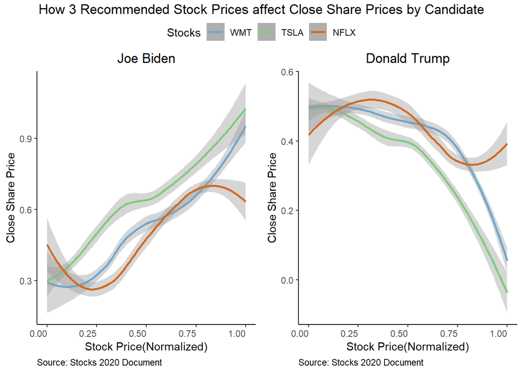

### **Model 2**

In this model, we wanted to depict the trends of each Candidate along with the Dow Jones. We recognize this only models the political factors, but in this study we noticed a steep Dow Jones decrease in March and rise in July. We found it interesting that the Dow Jones responded the way it did to the likelihood of each candidate winning.

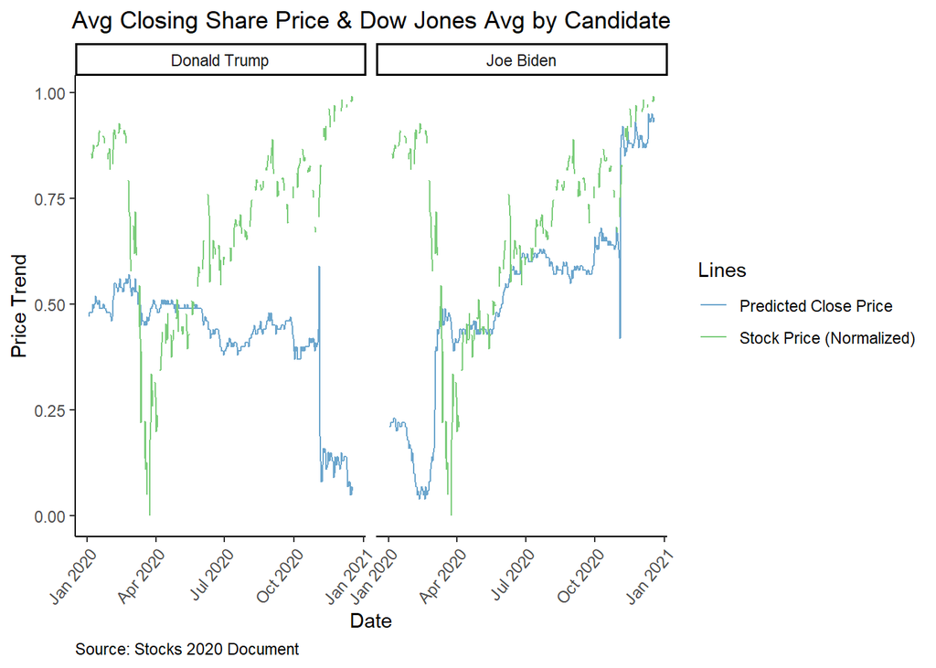

### **Model 3**

In this final model, we want to provide a view of the Dow Jones from April 1st to year end. The reason for April 1st is because that is when it was clear Joe Biden was selected to represent his party, while also the stock market was recovering a bit from the original shock of COVID-19. We look forward to further discussion as we move forward with our recommendations.

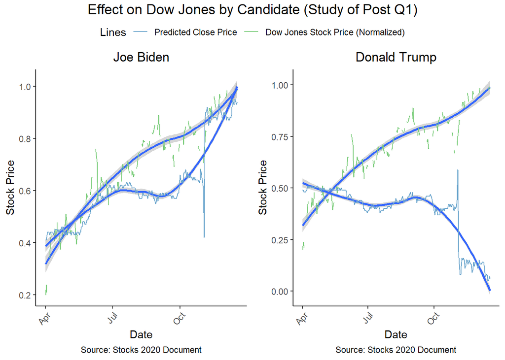